# Linear Regression: Day 4

Author

Constantin Manuel Bosancianu

Published

February 28, 2019

# 1 Introduction

We return to an old data set for today, the one we used in the first two days for the course. This is because it helps to discuss this topic with smaller data sets, where problematic observations can be reviewed with the help of additional data. After all, it might be hard to understand why respondent 1,037 has an extreme value on the outcome variable if we are unable to interview them again and find out more about them. If Texas has an extreme value, though, we might be able to search for background information which explains this.

The use of that data set also means that some of the problems we discussed in the lecture this morning might not appear. I am sure such “perfect storm” data sets exist out there, but the one from today is not that one. The code should still work the same, regardless of the results.

```r
library(pacman)
p_load(readstata13, tidyverse, lmtest, MASS, car, corrgram, kableExtra,
       magrittr, ggthemes)

# Avoid scientific notation for coefficients
options(scipen = 8)
```

Also define the centering function we wrote yesterday.

```r
fun_center <- function(x) {
    x - mean(x, na.rm = TRUE)
}
```

# 2 Reading data

We read in the data in `Stata` format again.

```r
df_sat <- read.dta13(file = "../02-data/01-Education-states.dta",
                    convert.factors = TRUE)
```

# 3 Initial estimation

Let’s run the model we last ran in class for this data.

```r
df_sat %<>%
    mutate(exp_scale = fun_center(expense),
           per_scale = fun_center(percent),
           region = as.character(region)) %>%
    mutate(neast = if_else(region == "N. East", 1, 0),
           region = if_else(is.na(region), "N. East", region),
           neast = if_else(state == "District of Columbia", 1, neast)) %>%
    dplyr::select(region, state, exp_scale, per_scale, income, csat, neast,
                  expense, percent) %>%
    na.omit()
```

```r
model1 <- lm(csat ~ exp_scale + per_scale + neast,
             data = df_sat,
             na.action = na.omit)

summary(model1)
```

```
Call:
lm(formula = csat ~ exp_scale + per_scale + neast, data = df_sat,
    na.action = na.omit)

Residuals:
    Min      1Q  Median      3Q     Max
-61.363 -19.619  -3.207  17.008  72.165

Coefficients:
              Estimate Std. Error t value Pr(>|t|)
(Intercept) 934.891177   5.114180 182.804  < 2e-16 ***
exp_scale     0.003477   0.004248   0.819  0.41718
per_scale    -2.856530   0.233554 -12.231 3.28e-16 ***
neast        46.954995  15.606341   3.009  0.00421 **
---
Signif. codes:  0 '***' 0.001 '**' 0.01 '*' 0.05 '.' 0.1 ' ' 1

Residual standard error: 29.26 on 47 degrees of freedom
Multiple R-squared:  0.8203,    Adjusted R-squared:  0.8089
F-statistic: 71.53 on 3 and 47 DF,  p-value: < 2.2e-16
```

# 4 Linearity

Are bivariate relationships truly linear? To check this, we have to make use of component-plus-residual plots. The `crPlot()` function is available in the `car` package.

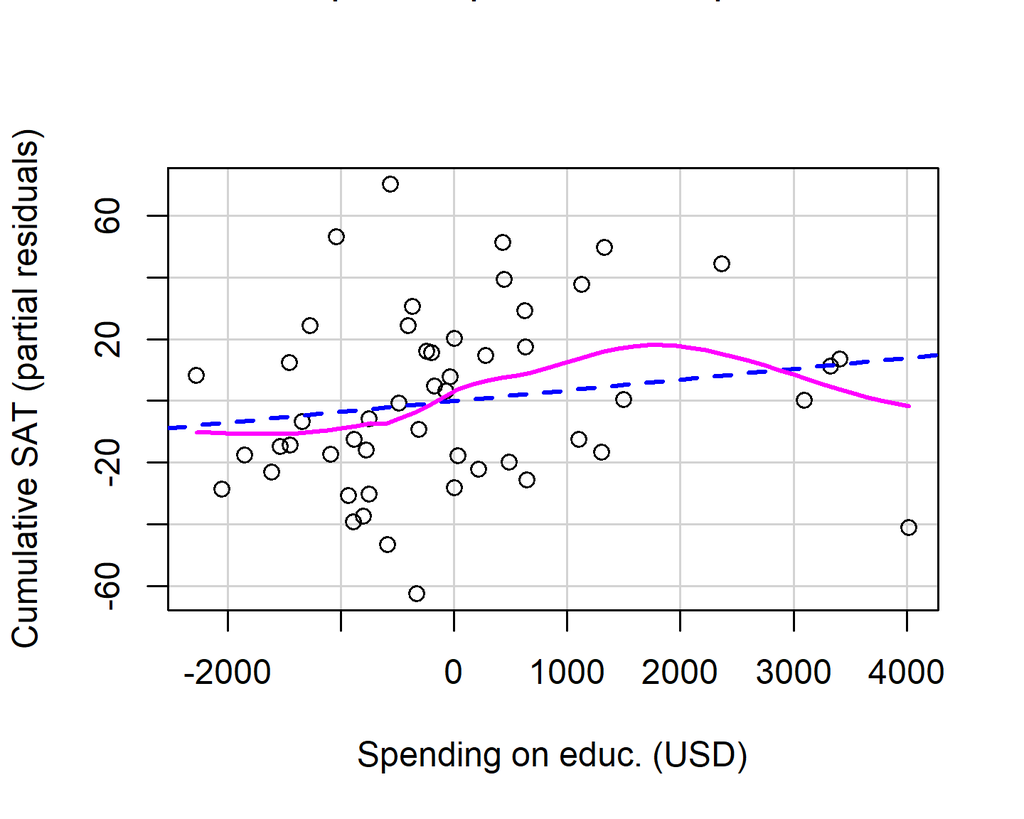

```r
crPlots(model1, "exp_scale",
        main = "Component-plus-residual plot",
        xlab = "Spending on educ. (USD)",
        ylab = "Cumulative SAT (partial residuals)")
```

It’s maybe a bit of a stretch to call this a linear relationship, but given that it’s a small sample, it’s perhaps reasonably close to a linear one. Let’s see what the other diagnostics tell us before we make a decision in this case.

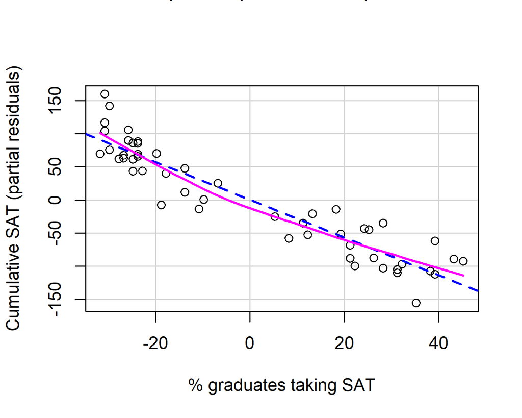

```r
crPlots(model1, "per_scale",
        main="Component-plus-residual plot",
        xlab = "% graduates taking SAT",
        ylab = "Cumulative SAT (partial residuals)")
```

# 5 Homoskedasticity

The `studres()` function is available in the `MASS` package, and is required to produce the studentized residuals we use in the plotting command below.

First, a plot of fitted values ($\hat{Y}$) against studentized residuals.

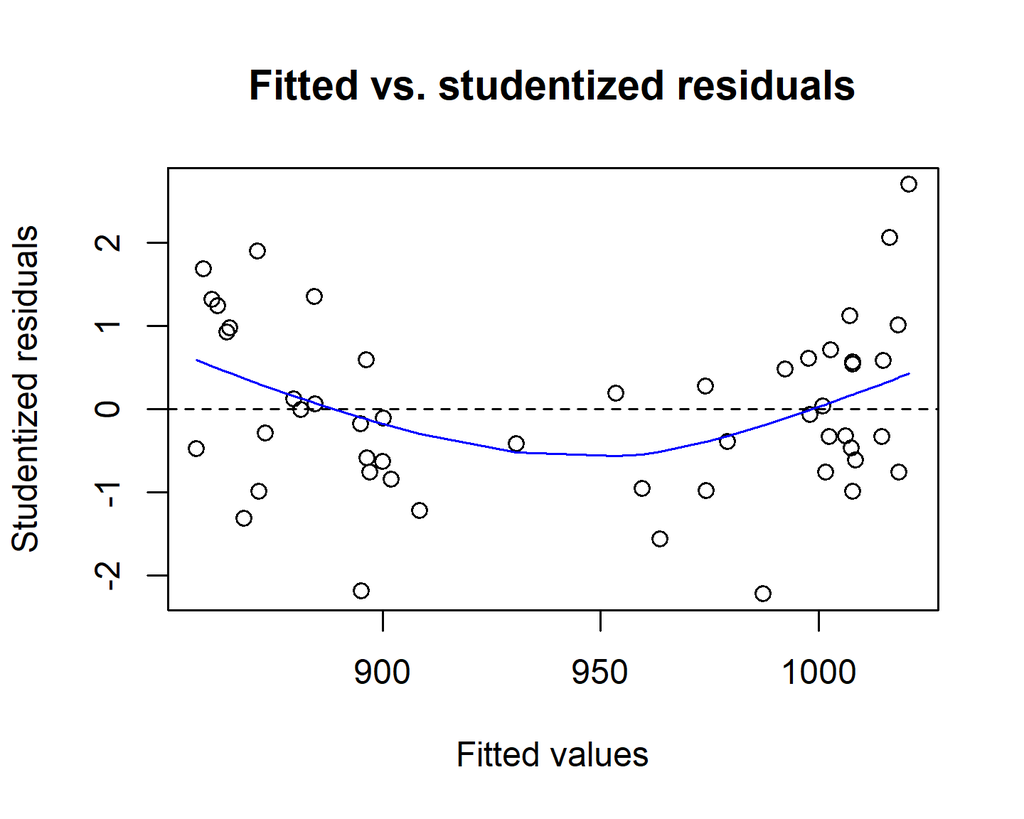

```r
plot(fitted(model1), studres(model1),
     xlab = "Fitted values",
     ylab = "Studentized residuals",
     main = "Fitted vs. studentized residuals")
abline(h = 0, lty = 2)
lines(lowess(fitted(model1), studres(model1)), col = "blue")
```

It’s a small sample size, so I would not automatically say that there is heteroskedasticity.

Second, generate plots of predictors against studentized residuals. This has to be done for each predictor included in the model, irrespective of whether categorical or continuous.

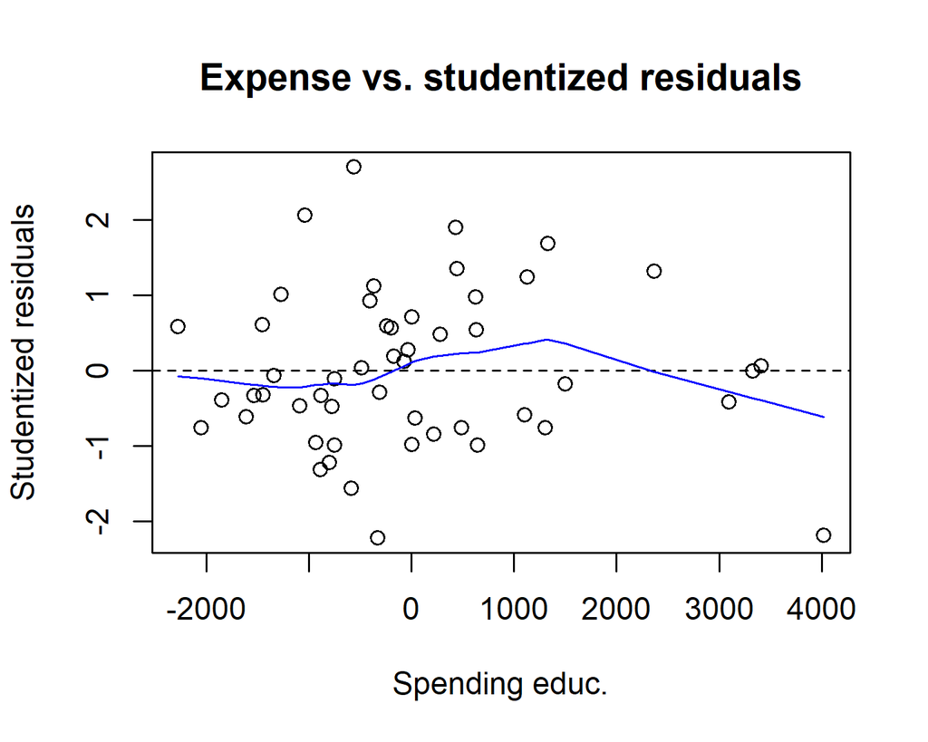

```r
plot(df_sat$exp_scale, studres(model1),
     xlab = "Spending educ.",
     ylab = "Studentized residuals",
     main = "Expense vs. studentized residuals")
abline(h = 0, lty = 2)
lines(lowess(df_sat$exp_scale, studres(model1)), col = "blue")
```

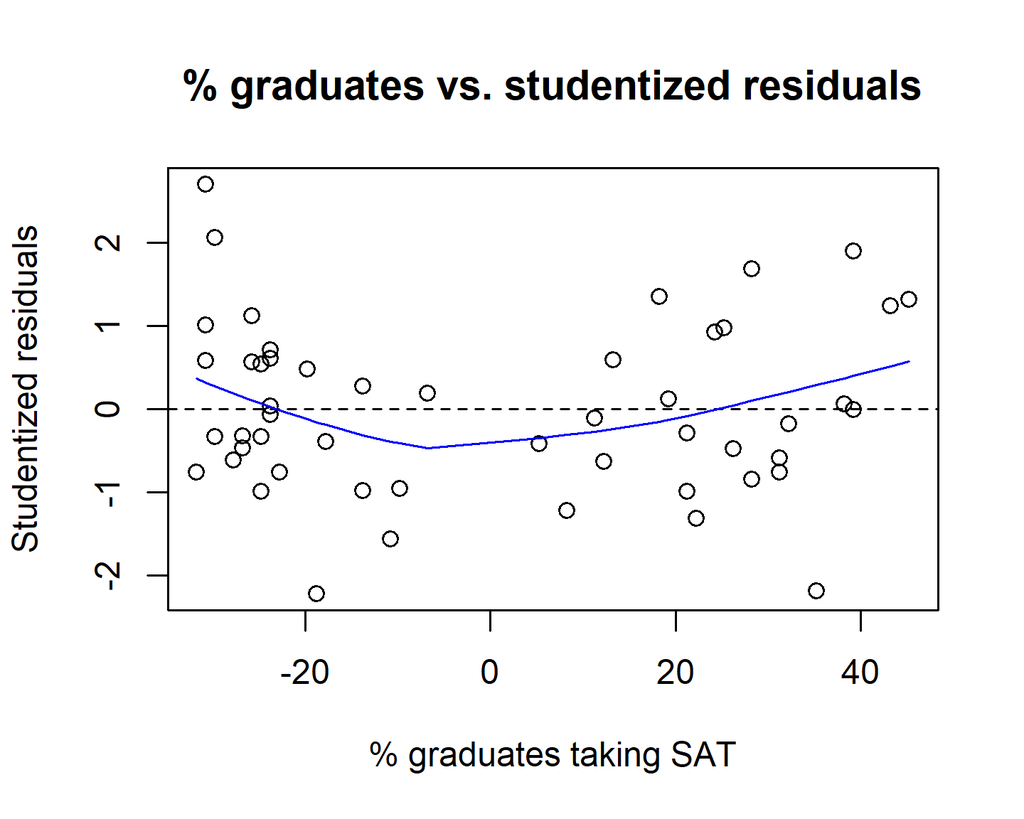

```r
plot(df_sat$per_scale, studres(model1),
     xlab = "% graduates taking SAT",
     ylab = "Studentized residuals",
     main = "% graduates vs. studentized residuals")
abline(h = 0, lty = 2)
lines(lowess(df_sat$per_scale, studres(model1)), col = "blue")
```

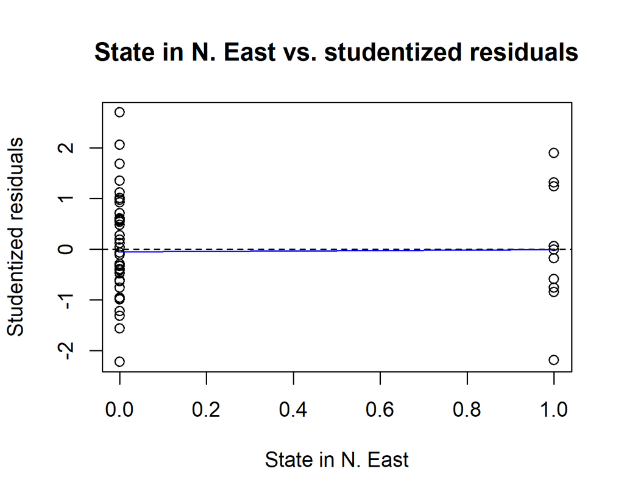

```r
plot(df_sat$neast, studres(model1),
     xlab = "State in N. East",
     ylab = "Studentized residuals",
     main = "State in N. East vs. studentized residuals")
abline(h = 0, lty = 2)
lines(lowess(df_sat$neast, studres(model1)), col = "blue")
```

A formal test for heteroskedasticity: Breusch-Pagan.

```r
bptest(model1)
```

```
    studentized Breusch-Pagan test

data:  model1
BP = 0.67528, df = 3, p-value = 0.879
```

# 6 Normality

We would need a quantile comparison plot in this case. The `qqPlot()` function is available from the `car` package.

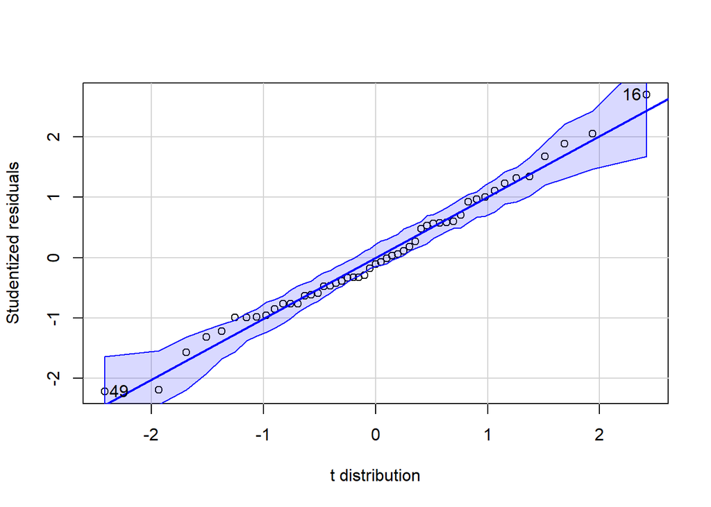

```
[1] 16 49
```

```r
qqPlot(model1,
       xlab = "t distribution",
       ylab = "Studentized residuals",
       id.method = "identify")
```

At least, overall, everything looks OK in terms of the normal distribution.

# 7 Specification error

What other factors could be influencing average SAT scores? It turns out that a good case can be made for income. With higher average incomes, more can be invested in a child’s education: special tutoring, books etc. At the same time, we might simply be dealing with reverse causality: in places with more capable students companies are interested in moving in and benefitting from the workforce, which means higher salaries.

Let’s say that it might be the first.

```r
df_sat %<>%
    mutate(inc_scale = fun_center(income))
```

```r
model2 <- lm(csat ~ exp_scale + per_scale + neast + inc_scale,
             data = df_sat,
             na.action = na.omit)
summary(model2)
```

```
Call:
lm(formula = csat ~ exp_scale + per_scale + neast + inc_scale,
    data = df_sat, na.action = na.omit)

Residuals:
    Min      1Q  Median      3Q     Max
-56.291 -17.814  -2.088  16.253  69.126

Coefficients:
              Estimate Std. Error t value Pr(>|t|)
(Intercept) 932.191419   4.785373 194.800  < 2e-16 ***
exp_scale    -0.003504   0.004514  -0.776 0.441589
per_scale    -3.232833   0.247015 -13.088  < 2e-16 ***
neast        60.723766  15.033665   4.039 0.000202 ***
inc_scale     2.867881   0.928775   3.088 0.003413 **
---
Signif. codes:  0 '***' 0.001 '**' 0.01 '*' 0.05 '.' 0.1 ' ' 1

Residual standard error: 26.92 on 46 degrees of freedom
Multiple R-squared:  0.8512,    Adjusted R-squared:  0.8382
F-statistic: 65.78 on 4 and 46 DF,  p-value: < 2.2e-16
```

There is an effect there, in the direction we expected. We also see that the effect of being in the Northeast of the US becomes stronger. Without this additional control we would have underestimated the SAT scores for Northeastern states.

# 8 Collinearity

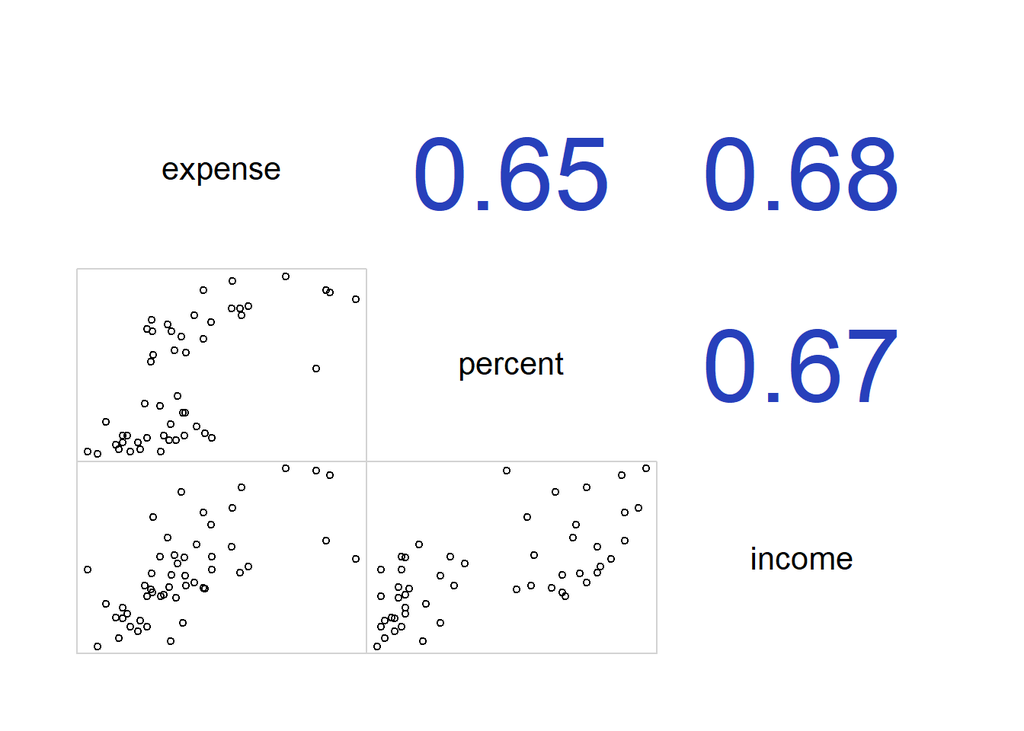

```r
corrgram(df_sat[ ,c("expense", "percent", "income")],
         lower.panel = panel.pts,
         upper.panel = panel.cor)
```

The correlations are pretty high here, but a bit below the threshold mentioned by Fox (2008). In survey-based research you will typically not see such high correlations.

# 9 Solving problems

## 9.1 Variable transformations

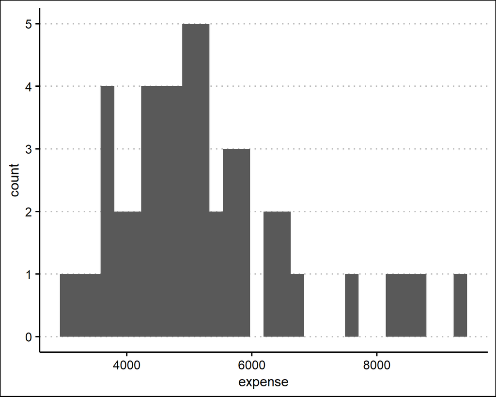

```r
ggplot(df_sat,
       aes(x = expense)) +
    geom_histogram() +
    theme_clean()
```

The distribution is a bit skewed here, which might be responsible for the problems we are seeing in the residuals. I will use a square root transformation.

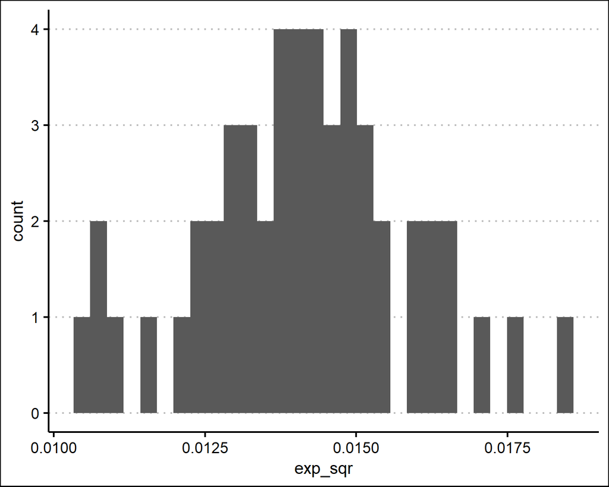

```r
df_sat %<>%
    mutate(exp_sqr = 1 / sqrt(expense))

ggplot(df_sat,
       aes(x = exp_sqr)) +
    geom_histogram() +
    theme_clean()
```

A little bit better, but still not completely normal.

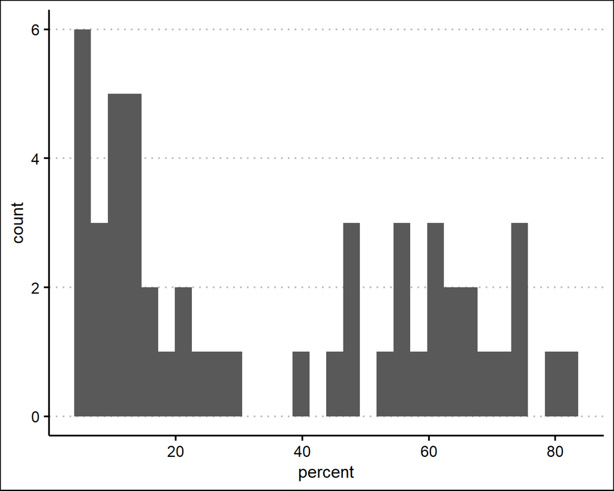

```r
ggplot(df_sat,
       aes(x = percent)) +
    geom_histogram() +
    theme_clean()
```

No transformation can solve this one.

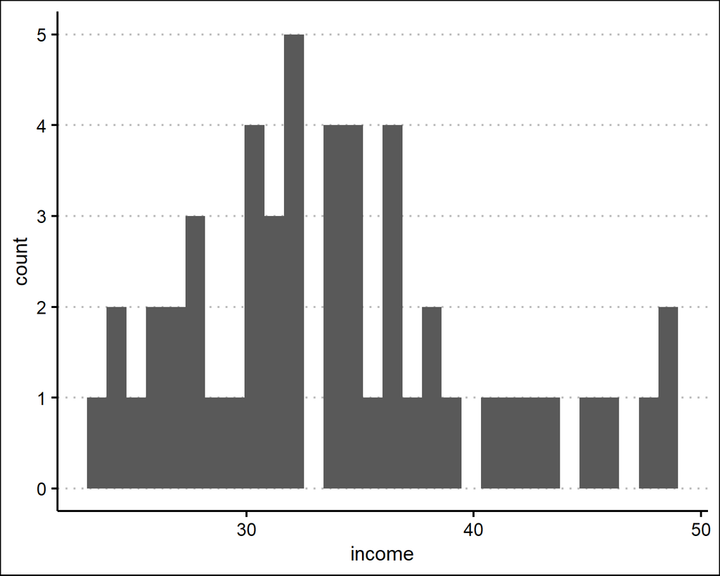

```r
ggplot(df_sat,
       aes(x = income)) +
    geom_histogram() +
    theme_clean()
```

A square root transformation could improve things a bit here as well, from which we take the inverse.

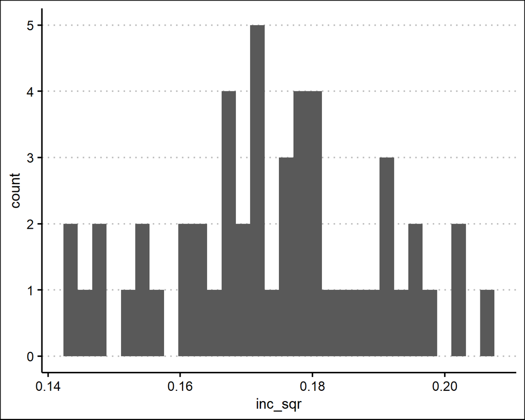

```r
df_sat %<>%
    mutate(inc_sqr = 1 / sqrt(income))

ggplot(df_sat,
       aes(x = inc_sqr)) +
    geom_histogram() +
    theme_clean()
```

There also seemed to be some problem with non-constant error mean in some of the plots that checked for heteroskedasticity.

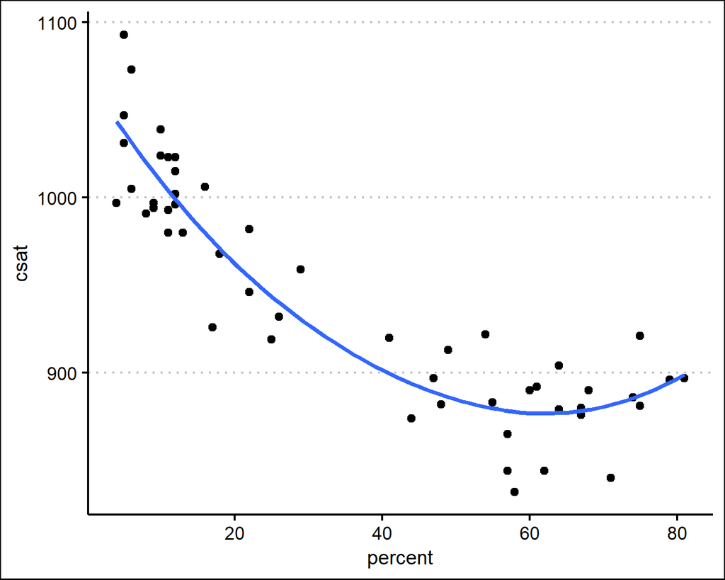

```r
ggplot(df_sat,
       aes(x = percent,
           y = csat)) +
    geom_point() +
    theme_clean() +
    geom_smooth(method = "loess",
                se = FALSE)
```

For `percent`, nothing really gets rid of the non-linearity. The biggest improvement was found for the inverse of the square root, which I used here.

```r
df_sat %<>%
    mutate(perc_sqr = 1 / sqrt(percent))
```

## 9.2 Re-estimating model

So let’s try for the model again, this time with the added `income` predictor, which came out as significant.

```r
model3 <- lm(csat ~ exp_sqr + perc_sqr + neast + inc_sqr,
             data = df_sat,
             na.action = na.omit)
summary(model3)
```

```
Call:
lm(formula = csat ~ exp_sqr + perc_sqr + neast + inc_sqr, data = df_sat,
    na.action = na.omit)

Residuals:
    Min      1Q  Median      3Q     Max
-81.073 -16.827  -1.169  17.881  49.758

Coefficients:
            Estimate Std. Error t value Pr(>|t|)
(Intercept)  1008.17      60.04  16.790  < 2e-16 ***
exp_sqr     -7928.02    3779.93  -2.097   0.0415 *
perc_sqr      639.38      53.60  11.929 1.12e-15 ***
neast         -19.07      12.92  -1.476   0.1467
inc_sqr      -529.71     378.63  -1.399   0.1685
---
Signif. codes:  0 '***' 0.001 '**' 0.01 '*' 0.05 '.' 0.1 ' ' 1

Residual standard error: 28.59 on 46 degrees of freedom
Multiple R-squared:  0.8322,    Adjusted R-squared:  0.8176
F-statistic: 57.04 on 4 and 46 DF,  p-value: < 2.2e-16
```

Some of the coefficients are different than before, but this is understandable given that we have changed the scale of measurement for some of these predictors.

Now we go through the checks again, starting with heteroskedasticity.

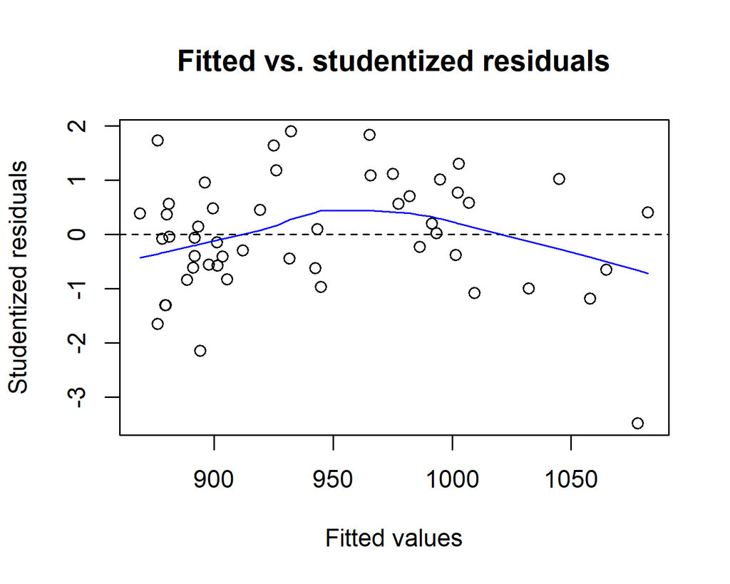

```r
plot(fitted(model3), studres(model3),
     xlab = "Fitted values",
     ylab = "Studentized residuals",
     main = "Fitted vs. studentized residuals")
abline(h = 0, lty = 2)
lines(lowess(fitted(model3), studres(model3)), col = "blue")
```

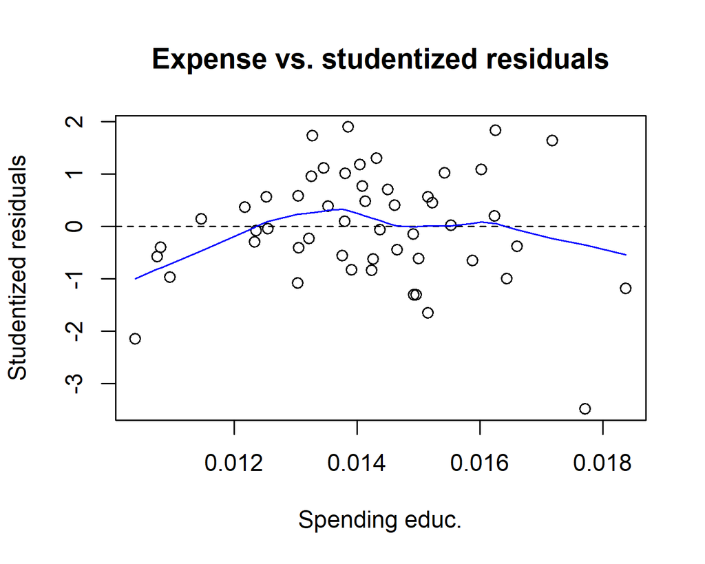

```r
plot(df_sat$exp_sqr, studres(model3),
     xlab = "Spending educ.",
     ylab = "Studentized residuals",
     main = "Expense vs. studentized residuals")
abline(h = 0, lty = 2)
lines(lowess(df_sat$exp_sqr, studres(model3)), col = "blue")
```

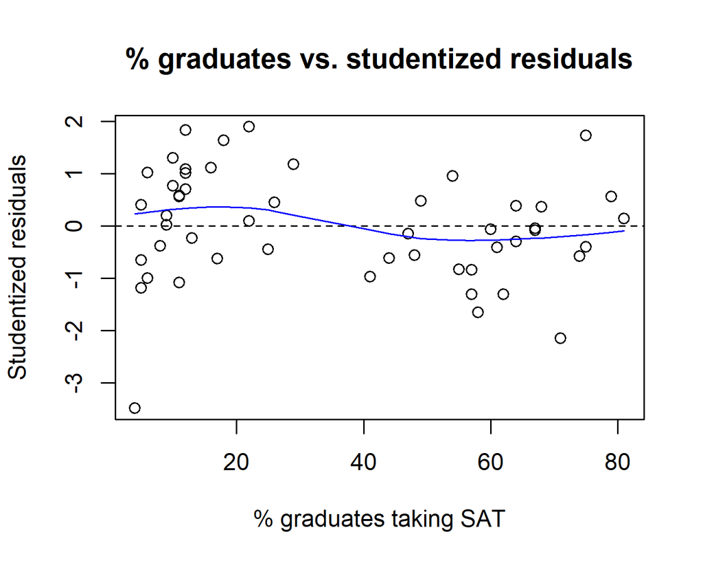

```r
plot(df_sat$percent, studres(model3),
     xlab = "% graduates taking SAT",
     ylab = "Studentized residuals",
     main = "% graduates vs. studentized residuals")
abline(h = 0, lty = 2)
lines(lowess(df_sat$percent, studres(model3)), col = "blue")
```

Finally, we check for normality in the residuals.

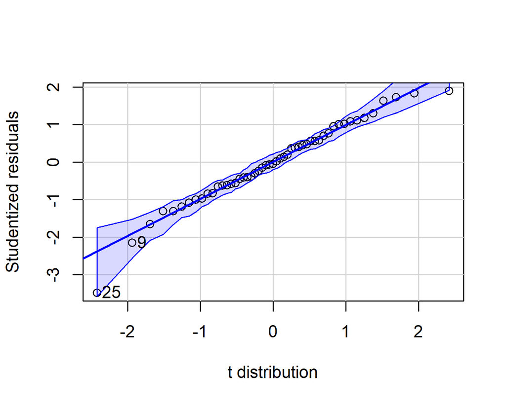

```
[1]  9 25
```

```r
qqPlot(model3,
       xlab = "t distribution",
       ylab = "Studentized residuals",
       id.method = "identify")
```

Not everything is perfect, but it might be as best as we can do under the circumstances.

# 10 Unusual and influential data

We did not get a chance to talk properly about this topic, but I am leaving the code in the slides, as you may need it when you will cover the chapters in Fox (2008) on your own.

We can simply run the initial model, for SAT scores and expense on education, again.

```r
model1 <- lm(csat ~ exp_scale + per_scale + neast,
             data = df_sat,
             na.action = na.omit)

summary(model1)
```

```
Call:
lm(formula = csat ~ exp_scale + per_scale + neast, data = df_sat,
    na.action = na.omit)

Residuals:
    Min      1Q  Median      3Q     Max
-61.363 -19.619  -3.207  17.008  72.165

Coefficients:
              Estimate Std. Error t value Pr(>|t|)
(Intercept) 934.891177   5.114180 182.804  < 2e-16 ***
exp_scale     0.003477   0.004248   0.819  0.41718
per_scale    -2.856530   0.233554 -12.231 3.28e-16 ***
neast        46.954995  15.606341   3.009  0.00421 **
---
Signif. codes:  0 '***' 0.001 '**' 0.01 '*' 0.05 '.' 0.1 ' ' 1

Residual standard error: 29.26 on 47 degrees of freedom
Multiple R-squared:  0.8203,    Adjusted R-squared:  0.8089
F-statistic: 71.53 on 3 and 47 DF,  p-value: < 2.2e-16
```

Let’s look at the relationship between expenditure and SAT score.

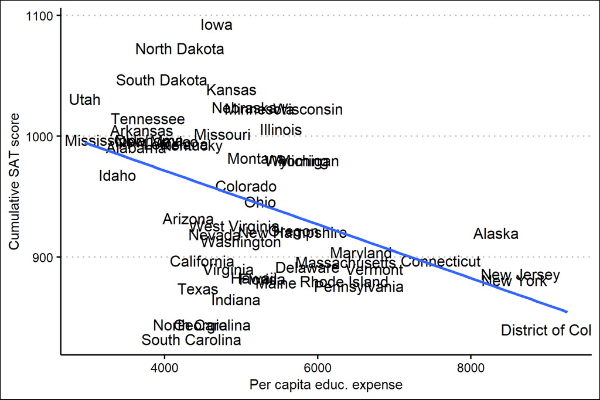

```r
ggplot(df_sat,
       aes(x = expense,
           y = csat,
           label = state)) +
    geom_text() +
    xlab("Per capita educ. expense") +
    ylab("Cumulative SAT score") +
    theme_clean() +
    geom_smooth(method = "lm",
                se = FALSE)
```

**Questions**:

1. How would you designate South Carolina, or Iowa? Are they outliers, or/and cases with high or low leverage? Are they influential cases or not?
2. How would you designate the District of Columbia? Is it an outlier, or/and an observation with high or low leverage? Is it an influential case or not?

## 10.1 Leverage

The `hatvalues()` function computes these hat values. Here, I add them to the data set.

```r
df_sat$hatv <- hatvalues(model1) # Store hat values in data frame
df_sat$row <- rownames(df_sat) # Create variable for row names, used in labeling points
```

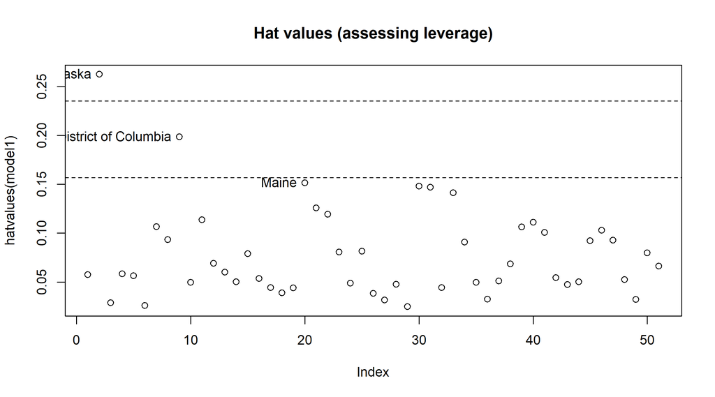

```r
plot(hatvalues(model1), # Plot the hat values
     main = "Hat values (assessing leverage)")

abline(h = c(2, 3) * 4 / length(df_sat$state), lty = 2) # Plot thresholds for hat values
with(subset(df_sat, df_sat$hatv >= 0.15),
     text(row, hatv, state, pos = 2)) # Label needed points
```

Remember, though, that for small samples, $3 \times$ average hat value is a better threshold than $2 \times$ average hat value.

## 10.2 Outliers

The `outlierTest()` function is available in the `car` package.

```r
outlierTest(model1)
```

```
No Studentized residuals with Bonferroni p < 0.05
Largest |rstudent|:
   rstudent unadjusted p-value Bonferroni p
16 2.698821          0.0096996      0.49468
```

Observation 16 is identified as perhaps a bit problematic (as long as no studentized residual has a Bonferroni $p < 0.05$, things are good), although the central message is that it’s not unusual to see such a residual in a sample as small as hours.

```r
df_sat[which(df_sat$row == 16), ]
```

```
    region state exp_scale per_scale income csat neast expense percent
16 Midwest  Iowa -556.9608 -30.76471 30.565 1093     0    4679       5
   inc_scale   exp_sqr   inc_sqr  perc_sqr       hatv row
16 -3.391569 0.0146192 0.1808789 0.4472136 0.05341696  16
```

## 10.3 Influence

I will plot here only Cook’s *D*, although a few other measures, such as **DFBETA** and **DFBETAS** have been proposed.

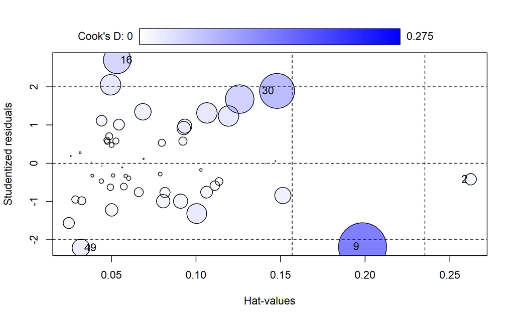

```
      StudRes        Hat      CookD
2  -0.4218008 0.26252074 0.01611507
9  -2.1897123 0.19847811 0.27465634
16  2.6988207 0.05341696 0.09063847
30  1.8902852 0.14803966 0.14716499
49 -2.2185781 0.03209272 0.03765770
```

```r
rownames(df_sat) <- df_sat$state

influencePlot(model1,
              xlab = "Hat-values",
              ylab = "Studentized residuals",
              id = list(method = "noteworthy"))
```

Because we specified “noteworthy” as a method, the function will use a set of pre-defined decision rules to label specific points in the plot that are worthy of inspection. If we had specified “identify” as a method, then the function would wait for you to click on the dots that you want labeled, and then for you to hit “Esc” when you’re done with labeling.

So which are those overlapping residuals?

```r
studres(model1)
```

```
          1           2           3           4           5           6
-0.61565063 -0.42180083 -0.95476728 -0.33398893 -0.11163705  0.18446181
          7           8           9          10          11          12
 1.31680657  0.96862728 -2.18971231 -0.62963013 -0.47779570  0.11558082
         13          14          15          16          17          18
-0.39138189  0.47510126 -0.28797817  2.69882066  1.11324901 -0.33025205
         19          20          21          22          23          24
-0.46984395 -0.84932044  1.68155100  1.23490929 -0.99350890  0.70437738
         25          26          27          28          29          30
-0.76338407  0.03102401  0.27162004  0.56310777 -1.56755655  1.89028523
         31          32          33          34          35          36
 0.05569051 -0.07309095 -0.01254645 -0.99010298  2.05395861 -0.98072728
         37          38          39          40          41          42
-0.32385679  1.34432679 -0.76143097 -0.59286339 -1.31811602  1.00689550
         43          44          45          46          47          48
 0.60086537 -1.21915789  0.57482511 -0.17807678  0.92152107  0.58343127
         49          50          51
-2.21857815  0.53593865 -0.76086611
```

```r
df_sat %>%
    filter(row %in% c(2, 9, 16, 30, 49)) %>%
    kable(caption = "5 problematic cases",
          caption.above = TRUE) %>%
    kable_styling(full_width = TRUE)
```

5 problematic cases

|  | region | state | exp_scale | per_scale | income | csat | neast | expense | percent | inc_scale | exp_sqr | inc_sqr | perc_sqr | hatv | row |
| --- | --- | --- | --- | --- | --- | --- | --- | --- | --- | --- | --- | --- | --- | --- | --- |
| Alaska | West | Alaska | 3094.0392 | 5.235294 | 48.254 | 920 | 0 | 8330 | 41 | 14.297431 | 0.0109566 | 0.1439572 | 0.1561738 | 0.2625207 | 2 |
| District of Columbia | N. East | District of Columbia | 4023.0392 | 35.235294 | 35.807 | 840 | 1 | 9259 | 71 | 1.850431 | 0.0103925 | 0.1671152 | 0.1186782 | 0.1984781 | 9 |
| Iowa | Midwest | Iowa | -556.9608 | -30.764706 | 30.565 | 1093 | 0 | 4679 | 5 | -3.391569 | 0.0146192 | 0.1808789 | 0.4472136 | 0.0534170 | 16 |
| New Hampshire | N. East | New Hampshire | 436.0392 | 39.235294 | 42.335 | 921 | 1 | 5672 | 75 | 8.378431 | 0.0132780 | 0.1536916 | 0.1154701 | 0.1480397 | 30 |
| West Virginia | South | West Virginia | -324.9608 | -18.764706 | 24.233 | 926 | 0 | 4911 | 17 | -9.723569 | 0.0142697 | 0.2031404 | 0.2425356 | 0.0320927 | 49 |